# 孤独症儿童睡眠特征与褪黑素水平的关联性分析

刘子佳

2026-07-10

# 1. 研究背景

孤独症谱系障碍（ASD）是一种神经发育障碍，全球儿童患病率约1%-2%。睡眠障碍是其最常见共病之一，发生率高达50%-80%，表现为入睡困难、夜间觉醒、睡眠时间缩短等。褪黑素是调节昼夜节律的核心激素，ASD儿童常存在褪黑素分泌节律异常，但其与睡眠特征的具体关联尚不明确。本研究基于横断面设计，探讨ASD儿童睡眠特征与清晨血清褪黑素水平的关系，并重点考察年龄对关联的影响。

# 2. 研究问题

- ASD伴睡眠障碍与不伴睡眠障碍儿童在CSHQ各维度得分及血清褪黑素水平上是否存在差异？
- 血清褪黑素水平与CSHQ总分、各维度得分及睡眠时长是否相关？
- 这种关联是否随年龄变化（年龄分层分析）？

# 3. 数据来源与研究对象

研究对象为2~15岁ASD儿童，来自残联、特教学校及康复机构。共收集140份有效问卷及清晨空腹血样。依据CSHQ总分>41分为睡眠障碍组（n=124），≤41分为非障碍组（n=16）。

# 4. 变量说明

| 变量名 | 类型 | 说明 |
| --- | --- | --- |
| group | 二分类 | 1=伴睡眠障碍，2=不伴睡眠障碍 |
| age | 连续 | 年龄（岁） |
| gender | 二分类 | 1=男，2=女 |
| mel | 连续 | 血清褪黑素浓度（pg/mL） |
| CSHQ总分 | 连续 | 睡眠问题总评分 |
| 八个维度 | 连续 | 就寝习惯、入睡潜伏、睡眠持续时间、睡眠焦虑、夜醒、异态睡眠、睡眠呼吸障碍、白天嗜睡 |
| 睡眠时长 | 连续 | 工作日/周末夜晚及总时长 |
| 异常指标 | 二分类 | 各维度是否超过异常界值 |
| sleep_standard | 二分类 | 睡眠时长是否达标（基于AASM推荐） |

# 5. 数据清洗

- **数据处理**：使用R 4.3，tidyverse包进行清洗和转换。数据清洗包括重命名列、删除冗余变量、转换分类变量为因子、定义后续分析常用的变量列表。
- **统计方法**：因多数变量偏态，采用Mann-Whitney U检验比较两组间差异，Kruskal-Wallis检验比较多组；分类变量使用卡方或Fisher精确检验；相关分析采用Spearman秩相关。年龄分层分析按2-3、4-5、6-7、8-15岁四组分别计算。
- **可视化**：箱线图展示两组褪黑素分布，散点图展示年龄分层相关性。

```r
#
df <- read.csv("C:/Users/hp/Desktop/论文数据/数据库的最终版.csv", fileEncoding = "UTF-8")

colnames(df) <- c(
  "group", "agegroup1", "agegroup2", "age", "gender", "mel1", "mel",
  "sleep_weeknight", "sleep_total_weekday", "sleep_weekend_night", "sleep_total_weekend",
  "CSHQ_total", "bedtime_resistance", "sleep_onset_delay", "sleep_duration",
  "sleep_anxiety", "night_waking", "parasomnia", "sleep_breathing", "daytime_sleepiness",
  "filter", "bedtime_abnormal", "onset_abnormal", "duration_abnormal",
  "anxiety_abnormal", "nightwaking_abnormal", "parasomnia_abnormal",
  "breathing_abnormal", "daytime_abnormal", "sleep_standard"
)
df <- df %>% select(-mel1, -filter) %>%
  mutate(
    group_f = factor(group, 1:2, c("伴睡眠障碍","不伴睡眠障碍")),
    gender_f = factor(gender, 1:2, c("男","女")),
    agegroup_f = factor(agegroup1, 1:4, c("2-3岁","4-5岁","6-7岁","8-15岁")),
    sleep_standard_f = factor(sleep_standard, 1:0, c("达标","未达标"))
  )
dims <- c("bedtime_resistance","sleep_onset_delay","sleep_duration","sleep_anxiety",
          "night_waking","parasomnia","sleep_breathing","daytime_sleepiness")
dims_cn <- c("就寝习惯","入睡潜伏","睡眠持续时间","睡眠焦虑","夜醒","异态睡眠","睡眠呼吸障碍","白天嗜睡")
abn <- c("bedtime_abnormal","onset_abnormal","duration_abnormal","anxiety_abnormal",
         "nightwaking_abnormal","parasomnia_abnormal","breathing_abnormal","daytime_abnormal")
sleep_vars <- c("sleep_weeknight","sleep_total_weekday","sleep_weekend_night","sleep_total_weekend")
sleep_cn <- c("工作日夜晚睡眠时长","工作日总睡眠时长","周末夜晚睡眠时长","周末总睡眠时长")
```

# 6.描述性统计

# 6.1 研究对象基本特征

共140例，男性109（77.9%），女性31（22.1%）；睡眠障碍组124例（88.6%）。两组性别分布无差异（p=1.000），但年龄分布有显著差异（伴障碍组中位6.0岁，不伴组中位6.0岁，但秩均值有差异，p=0.024），提示后续需控制年龄。

# 6.2睡眠特征比较

```r
# 各维度总体描述
tab_desc <- data.frame(
  维度 = dims_cn,
  中位数 = sapply(df[dims], function(x) round(median(x, na.rm = TRUE), 2)),
  IQR = sapply(df[dims], function(x) round(IQR(x, na.rm = TRUE), 2)),
  最小值 = sapply(df[dims], function(x) round(min(x, na.rm = TRUE), 2)),
  最大值 = sapply(df[dims], function(x) round(max(x, na.rm = TRUE), 2))
)
kable(tab_desc, caption = "表1 CSHQ各维度得分总体描述", digits = 2)
```

表1 CSHQ各维度得分总体描述

|  | 维度 | 中位数 | IQR | 最小值 | 最大值 |
| --- | --- | --- | --- | --- | --- |
| bedtime_resistance | 就寝习惯 | 12 | 3 | 6 | 16 |
| sleep_onset_delay | 入睡潜伏 | 1 | 1 | 1 | 3 |
| sleep_duration | 睡眠持续时间 | 5 | 3 | 3 | 9 |
| sleep_anxiety | 睡眠焦虑 | 6 | 2 | 4 | 11 |
| night_waking | 夜醒 | 3 | 1 | 3 | 9 |
| parasomnia | 异态睡眠 | 8 | 2 | 7 | 21 |
| sleep_breathing | 睡眠呼吸障碍 | 3 | 1 | 3 | 9 |
| daytime_sleepiness | 白天嗜睡 | 13 | 3 | 8 | 22 |

```r
# 两组比较
comp_vars <- c(dims, "mel")
comp_cn <- c(dims_cn, "血清褪黑素(pg/mL)")
tab_compare <- data.frame(
  变量 = comp_cn,
  伴障碍组 = sapply(comp_vars, function(col) {
    med <- df %>% filter(group_f == "伴睡眠障碍") %>% pull(!!sym(col)) %>% median(na.rm = TRUE)
    iqr <- df %>% filter(group_f == "伴睡眠障碍") %>% pull(!!sym(col)) %>% IQR(na.rm = TRUE)
    paste0(round(med, 1), " (", round(iqr, 1), ")")
  }),
  不伴障碍组 = sapply(comp_vars, function(col) {
    med <- df %>% filter(group_f == "不伴睡眠障碍") %>% pull(!!sym(col)) %>% median(na.rm = TRUE)
    iqr <- df %>% filter(group_f == "不伴睡眠障碍") %>% pull(!!sym(col)) %>% IQR(na.rm = TRUE)
    paste0(round(med, 1), " (", round(iqr, 1), ")")
  }),
  U = sapply(comp_vars, function(col) {
    res <- wilcox.test(df[[col]] ~ df$group_f, exact = FALSE)
    round(res$statistic, 2)
  }),
  P = sapply(comp_vars, function(col) {
    res <- wilcox.test(df[[col]] ~ df$group_f, exact = FALSE)
    round(res$p.value, 4)
  })
)
kable(tab_compare, caption = "表2 两组CSHQ各维度及褪黑素比较 [中位数(IQR)]", digits = 3)
```

表2 两组CSHQ各维度及褪黑素比较 [中位数(IQR)]

|  | 变量 | 伴障碍组 | 不伴障碍组 | U | P |
| --- | --- | --- | --- | --- | --- |
| bedtime_resistance | 就寝习惯 | 12 (2) | 9 (2) | 1702.5 | 0.000 |
| sleep_onset_delay | 入睡潜伏 | 2 (2) | 1 (0) | 1404.0 | 0.003 |
| sleep_duration | 睡眠持续时间 | 5 (3) | 3 (0) | 1533.5 | 0.000 |
| sleep_anxiety | 睡眠焦虑 | 7 (2) | 5.5 (1) | 1483.0 | 0.001 |
| night_waking | 夜醒 | 3 (1) | 3 (0) | 1183.0 | 0.113 |
| parasomnia | 异态睡眠 | 8 (2) | 7 (0) | 1422.0 | 0.003 |
| sleep_breathing | 睡眠呼吸障碍 | 3 (1) | 3 (0) | 1228.5 | 0.046 |
| daytime_sleepiness | 白天嗜睡 | 14 (3) | 10 (1.2) | 1735.5 | 0.000 |
| mel | 血清褪黑素(pg/mL) | 158.7 (130) | 122.1 (135.5) | 977.0 | 0.924 |

# 7.数据可视化

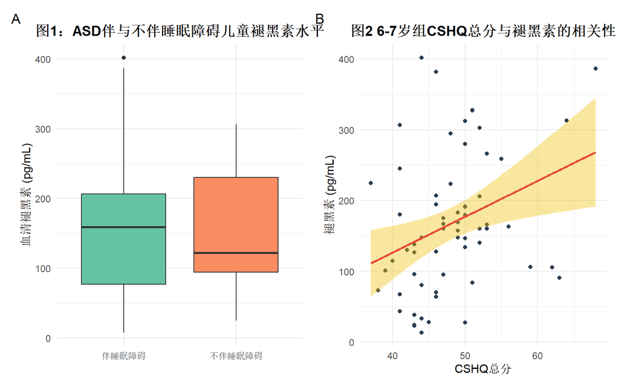

```r
# 图1：两组褪黑素箱线图
p1 <- ggplot(df, aes(x = group_f, y = mel, fill = group_f)) +
  geom_boxplot() +
  scale_fill_brewer(palette = "Set2") +
  labs(x = "", y = "血清褪黑素 (pg/mL)",
       title = "图1：ASD伴与不伴睡眠障碍儿童褪黑素水平") +
  theme_minimal() +
  theme(legend.position = "none",
        plot.title = element_text(hjust = 0.5, face = "bold"))

# 图2：6-7岁组散点图
df_6_7 <- df %>% filter(agegroup_f == "6-7岁")
p2 <- ggplot(df_6_7, aes(x = CSHQ_total, y = mel)) +
  geom_point(color = "#2c3e50") +
  geom_smooth(method = "lm", se = TRUE, color = "#e74c3c", fill = "#f1c40f") +
  labs(x = "CSHQ总分", y = "褪黑素 (pg/mL)",
       title = "图2 6-7岁组CSHQ总分与褪黑素的相关性") +
  theme_minimal() +
  theme(plot.title = element_text(hjust = 0.5, face = "bold"))

# 并排显示
library(patchwork)
p1 + p2 + plot_annotation(tag_levels = 'A')
```

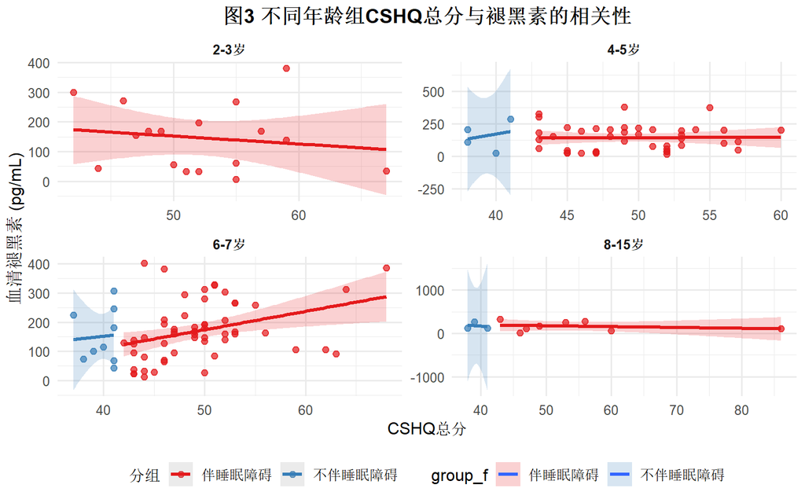

```r
# 图3：年龄分层散点图分面
# 该图展示四个年龄组内CSHQ总分与褪黑素的相关趋势，重点突出6-7岁组的正相关

library(ggplot2)
library(dplyr)

p3 <- ggplot(df, aes(x = CSHQ_total, y = mel, color = group_f)) +
  geom_point(alpha = 0.7, size = 2) +                     # 散点
  geom_smooth(method = "lm", se = TRUE, aes(fill = group_f), alpha = 0.2) +  # 线性回归拟合线
  facet_wrap(~ agegroup_f, scales = "free", nrow = 2) +   # 按年龄组分面，自由坐标轴
  labs(
    title = "图3 不同年龄组CSHQ总分与褪黑素的相关性",
    x = "CSHQ总分",
    y = "血清褪黑素 (pg/mL)",
    color = "分组"
  ) +
  scale_color_brewer(palette = "Set1") +   # 颜色方案
  scale_fill_brewer(palette = "Set1") +
  theme_minimal(base_size = 12) +
  theme(
    plot.title = element_text(hjust = 0.5, face = "bold"),
    legend.position = "bottom",
    strip.text = element_text(face = "bold")   # 分面标题加粗
  )

print(p3)
```

# 8.统计分析结果

整体样本中，褪黑素与CSHQ总分及所有维度、睡眠时长均无显著相关（p均>0.05）。

年龄分层后（关键发现）：

6-7岁组：CSHQ总分（r=0.357, p=0.003）和白天嗜睡（r=0.288, p=0.019）与褪黑素呈显著正相关。

其他年龄组未见显著相关。

```r
#年龄分层相关性分析
# ===== 表3：CSHQ总分与褪黑素年龄分层相关性 =====
age_lab <- c("2-3岁", "4-5岁", "6-7岁", "8-15岁")
cor_results <- data.frame(年龄组 = age_lab, n = NA, r = NA, P = NA)

for (i in seq_along(age_lab)) {
  sub <- df %>% filter(agegroup_f == age_lab[i])
  if (nrow(sub) >= 3) {
    ct <- cor.test(sub$mel, sub$CSHQ_total, method = "spearman", exact = FALSE)
    cor_results[i, c("n", "r", "P")] <- c(nrow(sub), round(ct$estimate, 3), round(ct$p.value, 4))
  } else {
    cor_results[i, c("n", "r", "P")] <- c(nrow(sub), NA, NA)
  }
}
cor_results$r <- ifelse(is.na(cor_results$r), "-", sprintf("%.3f", cor_results$r))
cor_results$P <- ifelse(is.na(cor_results$P), "-", sprintf("%.4f", cor_results$P))

kable(cor_results,
      caption = "表3 不同年龄组CSHQ总分与褪黑素的相关性",
      align = "c",
      col.names = c("年龄组", "样本量", "相关系数 r", "P值"),
      format = "html") %>%
  kable_styling(bootstrap_options = c("striped", "hover"), full_width = FALSE, font_size = 12) %>%
  column_spec(1, width = "6em") %>%
  column_spec(2, width = "4em") %>%
  column_spec(3, width = "6em") %>%
  column_spec(4, width = "6em")
```

表3 不同年龄组CSHQ总分与褪黑素的相关性

| 年龄组 | 样本量 | 相关系数 r | P值 |
| --- | --- | --- | --- |
| 2-3岁 | 17 | -0.149 | 0.5684 |
| 4-5岁 | 46 | -0.006 | 0.9688 |
| 6-7岁 | 66 | 0.357 | 0.0033 |
| 8-15岁 | 11 | -0.255 | 0.4500 |

```r
# 年龄分层后各维度与褪黑素的相关性
# ===== 表4：年龄分层相关性 =====
age_groups <- c("2-3岁","4-5岁","6-7岁","8-15岁")

res <- matrix("", length(dims), length(age_groups), dimnames = list(dims_cn, age_groups))
# 初始化字符矩阵，用于存放 "r (p)" 格式
for (i in seq_along(dims)) {
  for (j in seq_along(age_groups)) {
    sub <- df[df$agegroup_f == age_groups[j], ]
    if (nrow(sub) >= 3) {
      ct <- tryCatch(cor.test(sub[[dims[i]]], sub$mel, method = "spearman", exact = FALSE),
                     error = function(e) NULL)
      if (!is.null(ct)) {
        r <- round(ct$estimate, 3)
        p <- round(ct$p.value, 4)
        # 若 p 值极小，可显示为 "<0.0001"，这里统一保留4位小数
        res[i, j] <- paste0(sprintf("%.3f", r), " (", sprintf("%.4f", p), ")")
      }
    }
  }
}
# 将空字符串（未计算或失败）替换为 "-"
res[res == ""] <- "-"

# 转换为数据框
tab14 <- data.frame(维度 = rownames(res), res, row.names = NULL, check.names = FALSE)

# 输出表格
kable(tab14,
      caption = "表4 年龄分层后CSHQ各维度得分与褪黑素的相关性分析（r（P值））",
      align = "c", col.names = c("维度", age_groups), format = "html") %>%
  kable_styling(bootstrap_options = c("striped","hover"), full_width = TRUE, font_size = 12) %>%
  column_spec(1, width = "6em") %>%
  column_spec(2:5, width = "7em") %>%   # 加宽以容纳 "0.000 (0.0000)"
  scroll_box(width = "100%", height = "400px")
```

表4 年龄分层后CSHQ各维度得分与褪黑素的相关性分析（r（P值））

| 维度 | 2-3岁 | 4-5岁 | 6-7岁 | 8-15岁 |
| --- | --- | --- | --- | --- |
| 就寝习惯 | -0.062 (0.8124) | 0.048 (0.7512) | 0.180 (0.1489) | -0.060 (0.8601) |
| 入睡潜伏 | -0.043 (0.8699) | -0.103 (0.4937) | 0.194 (0.1193) | 0.000 (1.0000) |
| 睡眠持续时间 | -0.247 (0.3385) | 0.179 (0.2339) | 0.117 (0.3499) | 0.229 (0.4989) |
| 睡眠焦虑 | -0.032 (0.9025) | 0.002 (0.9920) | 0.178 (0.1525) | 0.009 (0.9787) |
| 夜醒 | 0.053 (0.8388) | 0.067 (0.6588) | -0.127 (0.3092) | -0.190 (0.5756) |
| 异态睡眠 | -0.382 (0.1303) | -0.114 (0.4494) | 0.199 (0.1090) | -0.542 (0.0852) |
| 睡眠呼吸障碍 | 0.241 (0.3519) | 0.009 (0.9522) | 0.059 (0.6403) | -0.178 (0.5998) |
| 白天嗜睡 | 0.097 (0.7117) | -0.018 (0.9045) | 0.288 (0.0191) | -0.406 (0.2149) |

# 9. 结果解释

本研究未发现ASD儿童睡眠障碍组与对照组在清晨褪黑素水平上的差异，整体上褪黑素与睡眠参数无显著关联，这与部分既往研究（如韩盼盼等发现负相关）不完全一致，可能由于检测时相不同（清晨vs.晨尿代谢物）及样本异质性。

但年龄分层分析结果显示：6-7岁组呈正相关。这提示年龄可能改变褪黑素与睡眠障碍的关系，或许与发育阶段受体敏感性、褪黑素合成能力变化有关。6-7岁正相关支持“受体脱敏代偿”假说。这一发现强调了未来研究需按年龄分层，并应采用夜间节律指标（如DLMO）和客观监测（如体动记录仪）以全面评估。

# 10. 局限性

①样本量不均衡（障碍组124 vs. 非障碍组16），降低统计效力，可能掩盖真实差异。

②单次清晨采血仅反映“残余”褪黑素，不能代表夜间分泌峰值或节律。

③CSHQ为主观报告，存在回忆偏倚，尤其夜醒等事件可能漏报。

④年龄分布不均衡（8-15岁仅11例），影响该组分析可靠性。

⑤未控制共病、药物等混杂因素。

# 11. 结论

ASD儿童睡眠障碍检出率高（88.6%），CSHQ可有效识别多数睡眠问题。

整体上，清晨血清褪黑素水平与睡眠特征无显著相关，但年龄分层发现6-7岁正相关，提示年龄是重要修饰因子。

未来需结合夜间褪黑素节律、客观睡眠监测及更大样本，以阐明褪黑素在ASD睡眠障碍中的动态作用。

# 12.个人总结

通过本次分析，我系统掌握了使用R进行临床数据清洗、描述性统计、非参数检验和相关性分析的完整流程。尤其在处理偏态分布数据和分层分析时，深入理解了统计方法的适用条件。本研究虽有局限，但年龄分层的发现提示了未来研究的方向。同时，我也体会到数据可视化对于呈现结果的重要性。后续将加强学习混合效应模型和纵向数据分析，以期更全面地解析复杂医学问题。